# Chapter6

Megha Khanduri

2023-12-11

# Chapter 6: Analysis of longitudinal data

Packages:

```r
options(repos = list(CRAN="http://cran.rstudio.com/"))

library(MASS)
library(corrplot)
library(readr)
library(dplyr)
library(tidyverse)
library(ggplot2)
library(GGally)
library(DT)
library(tibble)
library(tidyr)
```

Data:

```r
BPRS <- read.csv("BPRSL")
RATS <- read.csv("RATSL")
```

## The RATS dataset:

```r
DT::datatable(RATS, options = list(pageLength = 10))
```

|  | X | ID | Group | WD | Weight | Time |
| --- | --- | --- | --- | --- | --- | --- |
| 1 | 1 | 1 | 1 | WD1 | 240 | 1 |
| 2 | 2 | 2 | 1 | WD1 | 225 | 1 |
| 3 | 3 | 3 | 1 | WD1 | 245 | 1 |
| 4 | 4 | 4 | 1 | WD1 | 260 | 1 |
| 5 | 5 | 5 | 1 | WD1 | 255 | 1 |
| 6 | 6 | 6 | 1 | WD1 | 260 | 1 |
| 7 | 7 | 7 | 1 | WD1 | 275 | 1 |
| 8 | 8 | 8 | 1 | WD1 | 245 | 1 |
| 9 | 9 | 9 | 2 | WD1 | 410 | 1 |
| 10 | 10 | 10 | 2 | WD1 | 405 | 1 |

[output cut: 182 more lines]

The above data studies the temporal trends in the weight of rats, taking repeated measurements from each week, group and individual. These variables could potentially contribute to correlations between individual weights.

**Graphical Representation**

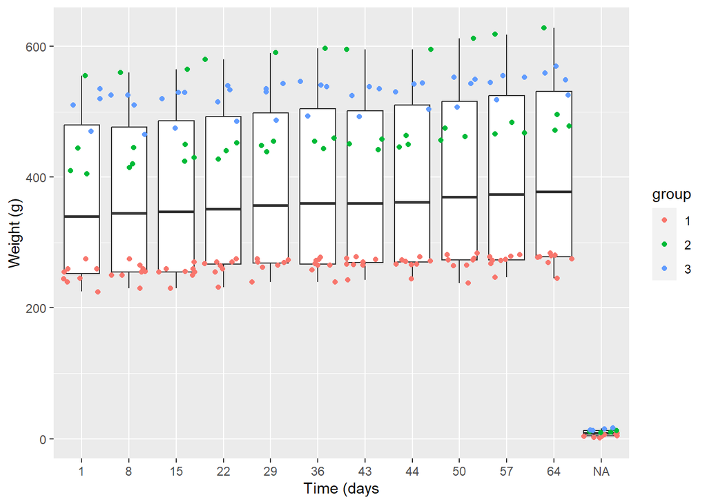

```r
RATS$timef <- factor(RATS$Time)
RATS$group <- factor(RATS$Group)
p <- ggplot(data = RATS, aes(x = timef, y = Weight)) + geom_boxplot() + geom_jitter(aes(col = group)) + xlab("Time (days") + ylab("Weight (g)")
p
```

Taking a closer look at each treatment:

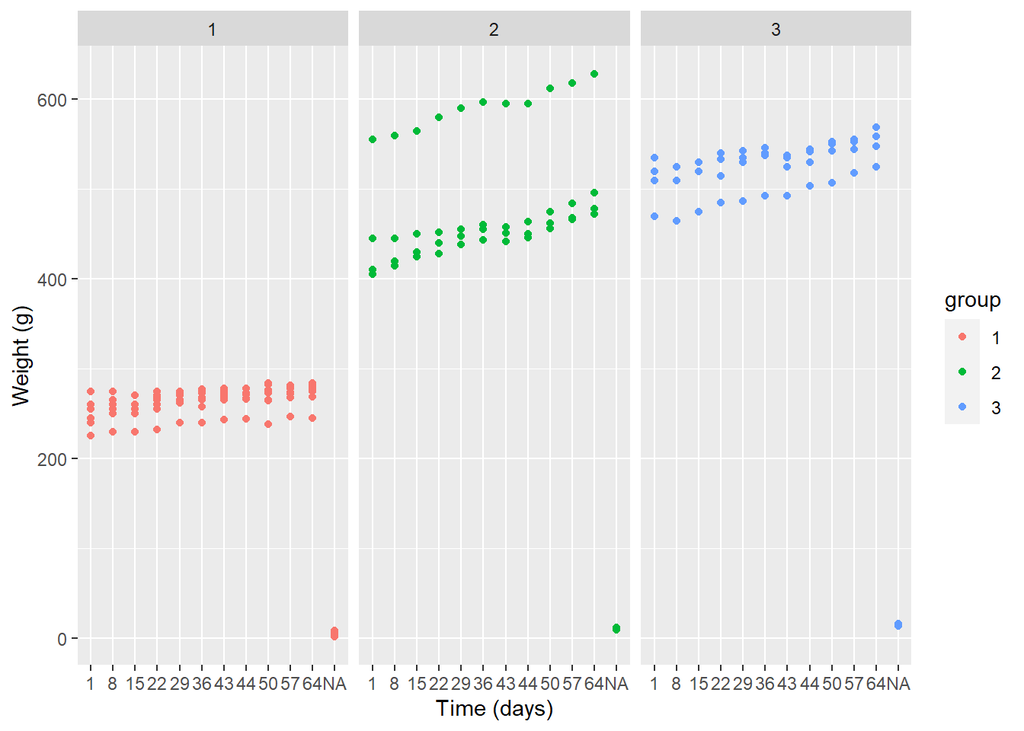

```r
p2 <- ggplot(data = RATS, aes(x = timef, y = Weight)) + geom_point(aes(col = group)) + xlab("Time (days)") + ylab("Weight (g)")

 p2 <- p2 + facet_wrap(~group)
 p2
```

There are quite some variations in Group 2. Wonder if these are contributed by the same individual. Let’s take a yet closer look at this group.

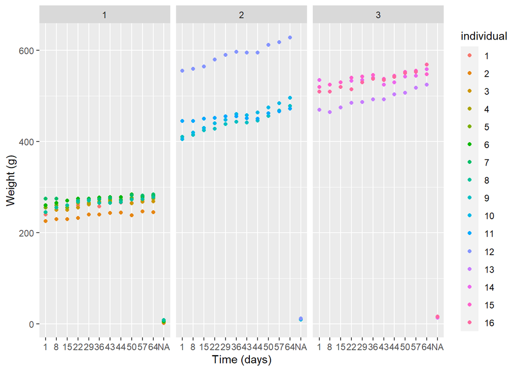

```r
RATS$individual <- factor(RATS$ID)

p3 <- ggplot(data = RATS, aes(x = timef, y = Weight)) + geom_point(aes(col = individual)) + xlab("Time (days)") + ylab("Weight (g)")

p3 <- p3 + facet_wrap(~group)
 p3
```

As suspected, the variation is contributed to by one individual, ID 12.

From the above graphs, it appears that time and group may have a significant influence on the weight of the individuals. The individuals themselves may present some variations, and these may need to be accounted for (especially ID 12).

We’ll try to see if our hypothesis is correct, using ANOVA.

```r
#let's create a summary dataset first
RATS.s <- RATS %>%
  filter(ID != 12) %>%                   #We'll remove ID 12, which is causing a lot of variation within Group 2
  group_by(Group, ID) %>%
  summarise( mean=mean(Weight) ) %>%
  ungroup()
glimpse(RATS.s)
```

```
## Rows: 15
## Columns: 3
## $ Group <int> 1, 1, 1, 1, 1, 1, 1, 1, 2, 2, 2, 3, 3, 3, 3
## $ ID    <int> 1, 2, 3, 4, 5, 6, 7, 8, 9, 10, 11, 13, 14, 15, 16
## $ mean  <dbl> 239.4167, 218.0000, 238.7500, 244.6667, 247.4167, 252.3333, 252.…
```

Let’s take a look at whether the graphical representation of the summarised data indicates any considerable differences in rat weights between groups.

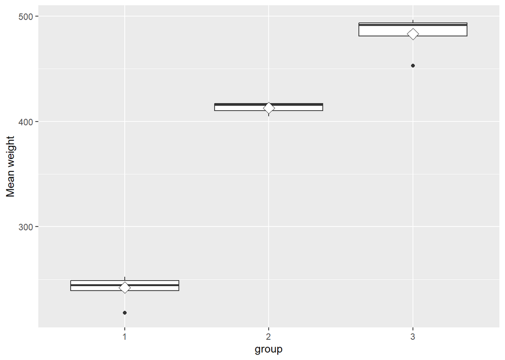

```r
RATS.s$group = factor(RATS.s$Group)
ggplot(RATS.s, aes(x = group, y = mean)) +
  geom_boxplot() +
  stat_summary(fun = "mean", geom = "point", shape=23, size=4, fill = "white") +
  scale_y_continuous(name = "Mean weight")
```

It looks like the mean weights may vary significantly between the three groups.

```r
lm_R1 <- lm(mean ~ Group + ID, data = RATS.s)
summary(lm_R1)
```

```
##
## Call:
## lm(formula = mean ~ Group + ID, data = RATS.s)
##
## Residuals:
##     Min      1Q  Median      3Q     Max
## -36.531 -11.843  -3.269   3.217  40.169
##
## Coefficients:
##             Estimate Std. Error t value Pr(>|t|)
## (Intercept)  127.622     13.979   9.130 9.49e-07 ***
## Group         98.425     18.460   5.332 0.000179 ***
## ID             5.119      3.376   1.516 0.155305
## ---
## Signif. codes:  0 '***' 0.001 '**' 0.01 '*' 0.05 '.' 0.1 ' ' 1
##
## Residual standard error: 23.77 on 12 degrees of freedom
## Multiple R-squared:  0.9616, Adjusted R-squared:  0.9552
## F-statistic: 150.4 on 2 and 12 DF,  p-value: 3.188e-09
```

```r
anova(lm_R1)
```

```
## Analysis of Variance Table
##
## Response: mean
##           Df Sum Sq Mean Sq  F value    Pr(>F)
## Group      1 168676  168676 298.5039 7.644e-10 ***
## ID         1   1299    1299   2.2995    0.1553
## Residuals 12   6781     565
## ---
## Signif. codes:  0 '***' 0.001 '**' 0.01 '*' 0.05 '.' 0.1 ' ' 1
```

It appears that the mean weights vary significantly by group (p=0), but not among individuals. (We’ll try to run the analysis with the outlier to see if that changes anything if there’s time)

## The BPRS data

```r
glimpse(BPRS)
```

```
## Rows: 360
## Columns: 6
## $ X         <int> 1, 2, 3, 4, 5, 6, 7, 8, 9, 10, 11, 12, 13, 14, 15, 16, 17, 1…
## $ treatment <int> 1, 1, 1, 1, 1, 1, 1, 1, 1, 1, 1, 1, 1, 1, 1, 1, 1, 1, 1, 1, …
## $ subject   <int> 1, 2, 3, 4, 5, 6, 7, 8, 9, 10, 11, 12, 13, 14, 15, 16, 17, 1…
## $ weeks     <chr> "week0", "week0", "week0", "week0", "week0", "week0", "week0…
## $ bprs      <int> 42, 58, 54, 55, 72, 48, 71, 30, 41, 57, 30, 55, 36, 38, 66, …
## $ week      <int> 0, 0, 0, 0, 0, 0, 0, 0, 0, 0, 0, 0, 0, 0, 0, 0, 0, 0, 0, 0, …
```

Converting variables to factors:

```r
BPRS$subject.f <- factor(BPRS$subject)
BPRS$week.f <- factor(BPRS$week)
BPRS$treatment.f <- factor(BPRS$treatment)
glimpse(BPRS)
```

```
## Rows: 360
## Columns: 9
## $ X           <int> 1, 2, 3, 4, 5, 6, 7, 8, 9, 10, 11, 12, 13, 14, 15, 16, 17,…
## $ treatment   <int> 1, 1, 1, 1, 1, 1, 1, 1, 1, 1, 1, 1, 1, 1, 1, 1, 1, 1, 1, 1…
## $ subject     <int> 1, 2, 3, 4, 5, 6, 7, 8, 9, 10, 11, 12, 13, 14, 15, 16, 17,…
## $ weeks       <chr> "week0", "week0", "week0", "week0", "week0", "week0", "wee…
## $ bprs        <int> 42, 58, 54, 55, 72, 48, 71, 30, 41, 57, 30, 55, 36, 38, 66…
## $ week        <int> 0, 0, 0, 0, 0, 0, 0, 0, 0, 0, 0, 0, 0, 0, 0, 0, 0, 0, 0, 0…
## $ subject.f   <fct> 1, 2, 3, 4, 5, 6, 7, 8, 9, 10, 11, 12, 13, 14, 15, 16, 17,…
## $ week.f      <fct> 0, 0, 0, 0, 0, 0, 0, 0, 0, 0, 0, 0, 0, 0, 0, 0, 0, 0, 0, 0…
## $ treatment.f <fct> 1, 1, 1, 1, 1, 1, 1, 1, 1, 1, 1, 1, 1, 1, 1, 1, 1, 1, 1, 1…
```

exploring the data graphically:

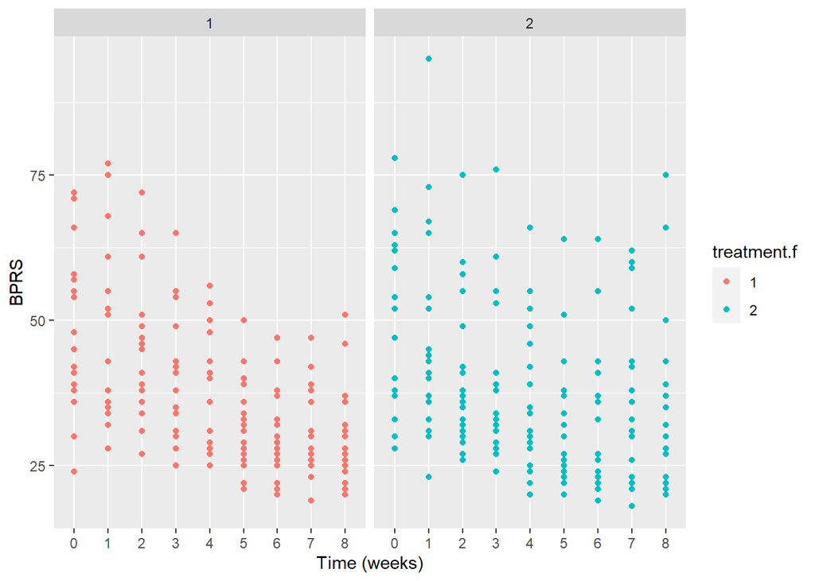

```r
library(ggplot2)
p4 <- ggplot(data = BPRS, aes(x = week.f, y = bprs)) + geom_point(aes(col = treatment.f)) + xlab("Time (weeks)") + ylab("BPRS")

p4 <- p4 + facet_wrap(~treatment.f)
 p4
```

Hmmm…. Not sure if treatment has a significant effect or not. Let’s try visualizing with a boxplot, maybe?

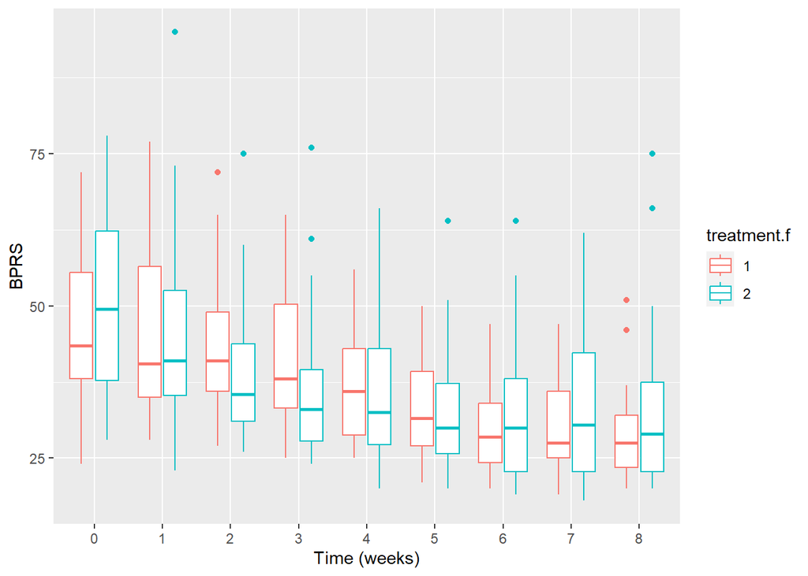

```r
p5 <- ggplot(data = BPRS, aes(x = week.f, y = bprs)) + geom_boxplot(aes(col = treatment.f)) + xlab("Time (weeks)") + ylab("BPRS")


 p5
```

The value of BPRS seems to be higher in treatment 2 in 5 out of 9 weeks. Either way, the value does decrease with each progressing week, so we may have a significant effect there.

Let’s see what a linear regression can tell us about this.

```r
lm.BPRS1<- lm(bprs~week, data = BPRS)

summary(lm.BPRS1)
```

```
##
## Call:
## lm(formula = bprs ~ week, data = BPRS)
##
## Residuals:
##     Min      1Q  Median      3Q     Max
## -22.740  -8.740  -3.388   6.889  50.530
##
## Coefficients:
##             Estimate Std. Error t value Pr(>|t|)
## (Intercept)  46.7400     1.2003  38.940   <2e-16 ***
## week         -2.2704     0.2521  -9.005   <2e-16 ***
## ---
## Signif. codes:  0 '***' 0.001 '**' 0.01 '*' 0.05 '.' 0.1 ' ' 1
##
## Residual standard error: 12.35 on 358 degrees of freedom
## Multiple R-squared:  0.1847, Adjusted R-squared:  0.1824
## F-statistic:  81.1 on 1 and 358 DF,  p-value: < 2.2e-16
```

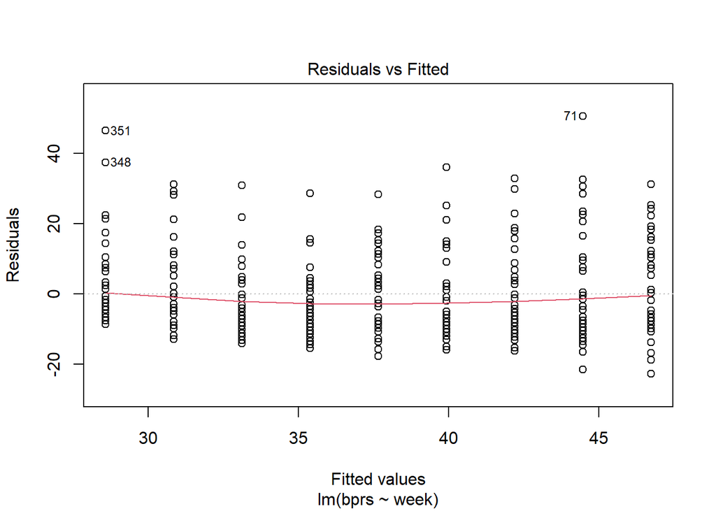

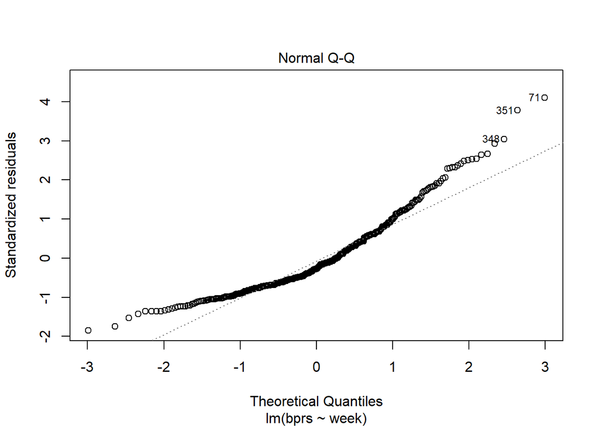

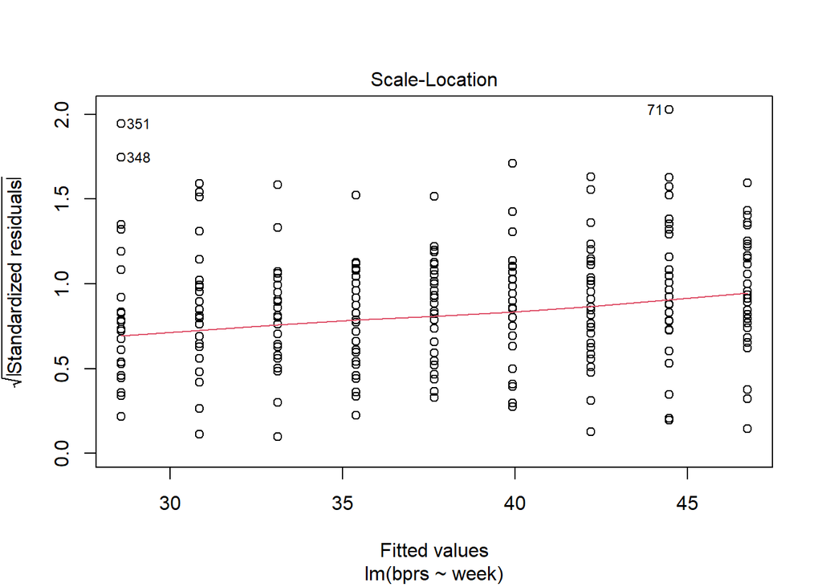

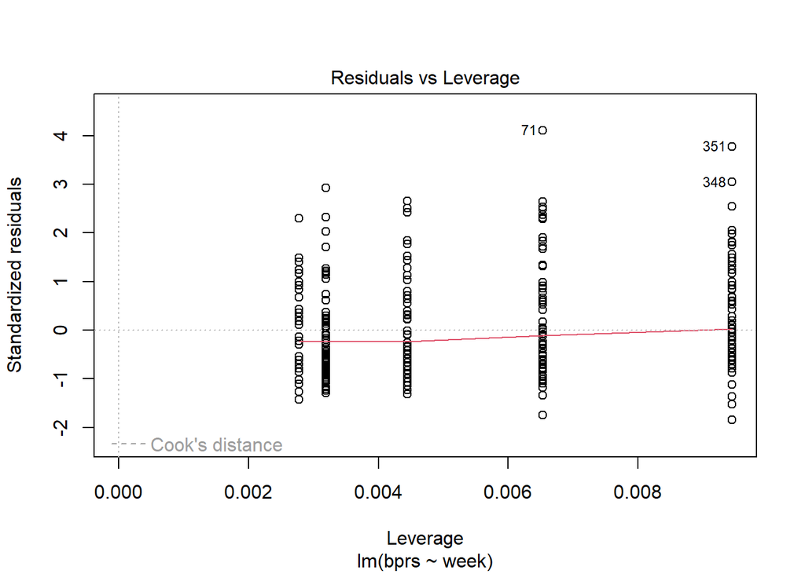

```r
plot(lm.BPRS1)
```

```r
anova(lm.BPRS1)
```

```
## Analysis of Variance Table
##
## Response: bprs
##            Df Sum Sq Mean Sq F value    Pr(>F)
## week        1  12372 12371.5  81.097 < 2.2e-16 ***
## Residuals 358  54613   152.6
## ---
## Signif. codes:  0 '***' 0.001 '**' 0.01 '*' 0.05 '.' 0.1 ' ' 1
```

So the week does appear to have a significant influence on the bprs.

Let’s give mixed modeling a try now

```r
library(lme4)
library(performance)

# Create a random intercept model
lmm.BPRS1 <- lmer(bprs ~ week + treatment + (1 | subject), data = BPRS, REML = FALSE)
summary(lmm.BPRS1)
```

```
## Linear mixed model fit by maximum likelihood  ['lmerMod']
## Formula: bprs ~ week + treatment + (1 | subject)
##    Data: BPRS
##
##      AIC      BIC   logLik deviance df.resid
##   2748.7   2768.1  -1369.4   2738.7      355
##
## Scaled residuals:
##     Min      1Q  Median      3Q     Max
## -3.0481 -0.6749 -0.1361  0.4813  3.4855
##
## Random effects:
##  Groups   Name        Variance Std.Dev.
##  subject  (Intercept)  47.41    6.885
##  Residual             104.21   10.208
## Number of obs: 360, groups:  subject, 20
##
## Fixed effects:
##             Estimate Std. Error t value
## (Intercept)  45.8817     2.4413  18.794
## week         -2.2704     0.2084 -10.896
## treatment     0.5722     1.0761   0.532
##
## Correlation of Fixed Effects:
##           (Intr) week
## week      -0.341
## treatment -0.661  0.000
```

```r
performance(lmm.BPRS1)
```

```
## # Indices of model performance
##
## AIC      |     AICc |      BIC | R2 (cond.) | R2 (marg.) |   ICC |  RMSE |  Sigma
## ---------------------------------------------------------------------------------
## 2745.198 | 2745.368 | 2764.629 |      0.440 |      0.186 | 0.313 | 9.953 | 10.208
```

As indicated by the “performance” function, the fixed effects (week and treatment) explain 18.6% of the variations in bprs (as indicated by marginal R2. But with the random effect, “subject”, as well, the model explains 44% of the variation (Conditional R2).

Let’s try another model without the treatment as a fixed effect.

```r
lmm.BPRS2 <- lmer(bprs ~ week +  (treatment | subject), data = BPRS, REML = FALSE)
summary(lmm.BPRS2)
```

```
## Linear mixed model fit by maximum likelihood  ['lmerMod']
## Formula: bprs ~ week + (treatment | subject)
##    Data: BPRS
##
##      AIC      BIC   logLik deviance df.resid
##   2582.8   2606.1  -1285.4   2570.8      354
##
## Scaled residuals:
##     Min      1Q  Median      3Q     Max
## -2.3026 -0.6034 -0.0675  0.4397  3.1714
##
## Random effects:
##  Groups   Name        Variance Std.Dev. Corr
##  subject  (Intercept) 376.73   19.410
##           treatment   189.16   13.754   -0.94
##  Residual              54.23    7.364
## Number of obs: 360, groups:  subject, 20
##
## Fixed effects:
##             Estimate Std. Error t value
## (Intercept)  46.6461     1.6586   28.12
## week         -2.2704     0.1503  -15.10
##
## Correlation of Fixed Effects:
##      (Intr)
## week -0.363
```

```r
performance(lmm.BPRS2)
```

```
## # Indices of model performance
##
## AIC      |     AICc |      BIC | R2 (cond.) | R2 (marg.) |   ICC |  RMSE | Sigma
## --------------------------------------------------------------------------------
## 2582.011 | 2582.249 | 2605.328 |      0.883 |      0.074 | 0.874 | 6.971 | 7.364
```

A random intercept and random slope give us a model with lower AIC. Let’s compare the two models using ANOVA now.

```r
anova(lmm.BPRS1)
```

```
## Analysis of Variance Table
##           npar  Sum Sq Mean Sq  F value
## week         1 12371.5 12371.5 118.7136
## treatment    1    29.5    29.5   0.2828
```

```r
anova(lmm.BPRS2)
```

```
## Analysis of Variance Table
##      npar Sum Sq Mean Sq F value
## week    1  12372   12372  228.14
```

```r
anova(lmm.BPRS1, lmm.BPRS2)
```

```
## Data: BPRS
## Models:
## lmm.BPRS1: bprs ~ week + treatment + (1 | subject)
## lmm.BPRS2: bprs ~ week + (treatment | subject)
##           npar    AIC    BIC  logLik deviance  Chisq Df Pr(>Chisq)
## lmm.BPRS1    5 2748.7 2768.1 -1369.4   2738.7
## lmm.BPRS2    6 2582.8 2606.1 -1285.4   2570.8 167.94  1  < 2.2e-16 ***
## ---
## Signif. codes:  0 '***' 0.001 '**' 0.01 '*' 0.05 '.' 0.1 ' ' 1
```

Let’s see if an interaction variable works better.

```r
lmm.BPRS3 <- lmer(bprs ~  week * treatment + (1 | subject), data = BPRS, REML = FALSE)
summary(lmm.BPRS3)
```

```
## Linear mixed model fit by maximum likelihood  ['lmerMod']
## Formula: bprs ~ week * treatment + (1 | subject)
##    Data: BPRS
##
##      AIC      BIC   logLik deviance df.resid
##   2747.7   2771.1  -1367.9   2735.7      354
##
## Scaled residuals:
##     Min      1Q  Median      3Q     Max
## -3.2038 -0.6641 -0.0846  0.4837  3.6049
##
## Random effects:
##  Groups   Name        Variance Std.Dev.
##  subject  (Intercept)  47.46    6.889
##  Residual             103.31   10.164
## Number of obs: 360, groups:  subject, 20
##
## Fixed effects:
##                Estimate Std. Error t value
## (Intercept)     50.1767     3.4828  14.407
## week            -3.3442     0.6561  -5.097
## treatment       -2.2911     1.9755  -1.160
## week:treatment   0.7158     0.4149   1.725
##
## Correlation of Fixed Effects:
##             (Intr) week   trtmnt
## week        -0.754
## treatment   -0.851  0.797
## week:trtmnt  0.715 -0.949 -0.840
```

```r
performance(lmm.BPRS3)
```

```
## # Indices of model performance
##
## AIC      |     AICc |      BIC | R2 (cond.) | R2 (marg.) |   ICC |  RMSE |  Sigma
## ---------------------------------------------------------------------------------
## 2744.164 | 2744.402 | 2767.481 |      0.445 |      0.190 | 0.315 | 9.909 | 10.164
```

```r
anova(lmm.BPRS3)
```

```
## Analysis of Variance Table
##                npar  Sum Sq Mean Sq  F value
## week              1 12371.5 12371.5 119.7527
## treatment         1    29.5    29.5   0.2853
## week:treatment    1   307.5   307.5   2.9760
```

Still no significant effect of the week*treatment

```r
anova(lmm.BPRS1,lmm.BPRS2,lmm.BPRS3)
```

```
## Data: BPRS
## Models:
## lmm.BPRS1: bprs ~ week + treatment + (1 | subject)
## lmm.BPRS2: bprs ~ week + (treatment | subject)
## lmm.BPRS3: bprs ~ week * treatment + (1 | subject)
##           npar    AIC    BIC  logLik deviance  Chisq Df Pr(>Chisq)
## lmm.BPRS1    5 2748.7 2768.1 -1369.4   2738.7
## lmm.BPRS2    6 2582.8 2606.1 -1285.4   2570.8 167.94  1  < 2.2e-16 ***
## lmm.BPRS3    6 2747.8 2771.1 -1367.9   2735.8   0.00  0
## ---
## Signif. codes:  0 '***' 0.001 '**' 0.01 '*' 0.05 '.' 0.1 ' ' 1
```

The second model remains the significant model out of the three mixed models.